# Reproducible Research in R

Ilya Kashnitsky

14 December 2016

# Reproducible research

# Reproducibility

- Reproducibility of scientific results is the main challenge of the modern academia
- Collaboration, Open Science (2015). Estimating the reproducibility of psychological science. *Science*, 349(6251), aac4716. https://doi.org/10.1126/science.aac4716
- Out of 100 papers only 39 were replicated

# Literate programming

- The idea of [literate programming](http://www.literateprogramming.com) dates back to mid-80s
- The core idea: code, comments, and results should appear together in one document.

Peng, R. D. (2011). Reproducible Research in Computational. *Science*, 334(6060), 1226â€“1227. https://doi.org/10.1126/science.1213847

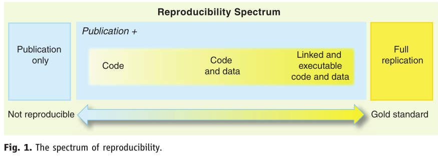

# markdown

# What is markdown?

Markdown is a lightweight markup language with plain text formatting syntax designed so that it can be converted to HTML and many other formats using a tool by the same name.

# Where is it used?

- Everywhere
- Reddit
- StackOverflow
- github
- Publons
- Habrahabr
- …

# The basics of markdown

- Basically, everything is just plain text unless modified
- Be careful. There are n+1 versions of markdown.
- The most popular are: GFM, rmarkdown and pandoc

[interactive chart not shown]

http://rmarkdown.rstudio.com/authoring_basics.html

# Task

Create a webpage using markdown.  
Use as many markdown options as you can think of. Include image, gif, video, link…

http://txti.es  
10 minutes

The author of txti, Barry T. Smith, is a great advocate of lightweight websites  
http://motherfuckingwebsite.com

# rmarkdown

[interactive chart not shown]

http://rmarkdown.rstudio.com

[interactive chart not shown]

https://bookdown.org/yihui/bookdown/

# R notebooks

- The [recently presented](https://blog.rstudio.org/2016/11/01/announcing-rstudio-v1-0/) v1.0 version of RStudio brings R-notebooks as on of the main features.
- This type of document implements the principles of literate programming.

[interactive chart not shown]

http://www.danielwells.me/human-lifespan-limit/

# Example

- [My application to Rostock Retreat](https://ikashnitsky.github.io/doc/misc/application-rostock-retreat/application-ik.nb.html)
- Please follow me on the Rmd script `"161126-application-ik.Rmd"`

# Presentations with R

# Easy and impressive

[figure not shown]

# Numerous frameworks for creating presentations with R

[interactive chart not shown]

http://rmarkdown.rstudio.com/formats.html

[interactive chart not shown]

https://ramnathv.github.io/slidifyExamples

# My choice: revealjs

[interactive chart not shown]

http://lab.hakim.se/reveal-js/

# Advantages of HTML5 presentations

- Open in any browser
- Put online
- Dynamic fit to screen (4:3 or 16:9 ?)
- Animated contents
- Fast to create
- Enforce KISS

[interactive chart not shown]

http://rmarkdown.rstudio.com/revealjs_presentation_format.html

# Example

- Please follow me on the Rmd script `"161209-R-ggplot.Rmd"`

# What’s next?

# `swirl`

[interactive chart not shown]

http://swirlstats.com

# Coursera: Data Science

https://www.coursera.org/specializations/jhu-data-science

# R-bloggers

[interactive chart not shown]

https://www.r-bloggers.com

# I believe, that it is the right time for you to master R while writing your master thesis.